# Estimating Renal (Kidney) Function App

January 27, 2017

## Renal Function Estimation

- Renal function is routinely tested in clinical practice for making decisions about diagnosis and treatments.
- The renal function is estimated based on the blood (serum) levels of a compound called creatinine. This estimation is part of the routine clinical chemistry panel that doctors order
- Using the demographic characteristics of the patient (age, race, gender) and the creatinine level the renal function is estimated using some well validated equations that were developed
- The US FDA in their guidance describes two equations that are routinely used for the estimation of renal function. These two equations are the Cockcroft-Gault equation and the Modification of diet in renal disease (MDRD)equation

## Cockcroft-Gault Equation and MDRD equation

The Cockcroft-Gault equation estimates the creatinine clearance Creatinine clearance (mL/min)={((140-age) x weight)/(72xSCr)}x 0.85 (if female).

The MDRD equation estimates the glomerular filtration rate GFR (mL/min/1.73 m2) = 175 × (Scr)^-1.154 × (Age)^-0.203 × (0.742 if female) × (1.212 if African American) where age is in years, weight in kg and serum creatininne(Scr) in mg/dL

The Renal function is divided into 5 categories Normal (eGFR or creatinine clearance >=90); Mild renal impairment(eGFR or creatinine clearance 60 to <90);Moderate renal impairment(eGFR or creatinine clearance 30 to <60);Severe renal impairment(eGFR or creatinine clearance 15 to <30);End Stage Renal Disease(eGFR or creatinine clearance <15)

## App for Estimating the Renal Function

The app layout is shown in the figure below

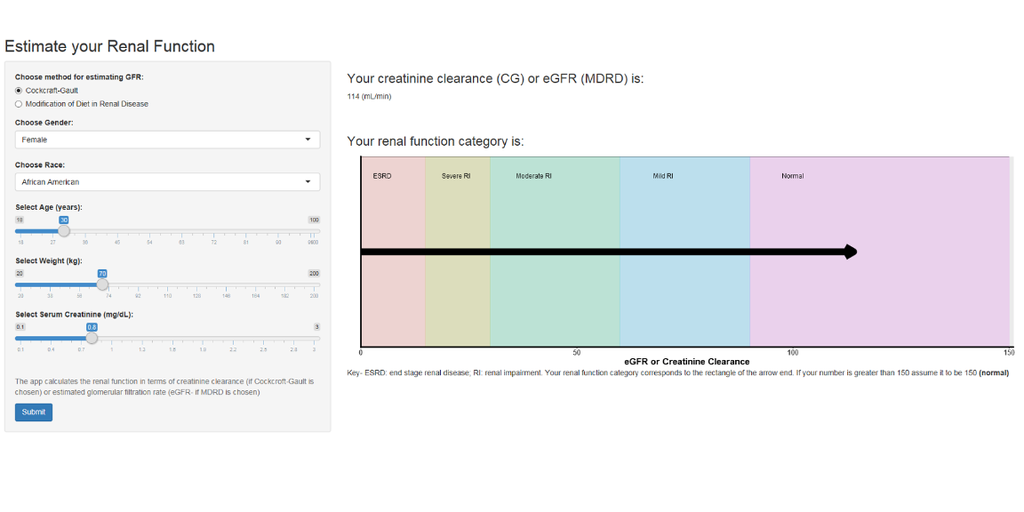

You select the method and use the dropdowns to select gender and race. Use the sliders to enter age, weight, and serum creatinine. Press submit to get the results of your renal function. You will have results as a numeric value and your renal function category in the figure

## An Example

Suppose we want to estimate the renal function of a 60 year old white male with serum creatinine of 0.9 mg/dL and weight of 80 kg.

```r
Age<-60; Weight<-80; Creatinine<-0.9; sexfac<-1; racefac<-1
crcl<-round(((140-Age)*Weight)*sexfac/(72*Creatinine),0) # CG
gfr<- round(175*(Creatinine)**-1.154*(Age)**-0.203*sexfac*racefac,0) # MDRD
print(crcl)# 99
print(gfr)# 86
```

## Additional Details

The app documentation including the code files (ui.R and server.R ) as well as the app html file are located at

https://github.com/aamrite/ShinyAppRenalFunctionEstimation

The app is hosted at https://aamrite.shinyapps.io/EstimateRenalFunction/